# 218x Assignment 1

Lange Luntao

12/5/2020

INSTRUCTIONS

*Part 1:*

*Create bar or line charts showing monthly total kBTUs of residential and commercial electricity and gas consumption for the Bay Area (meaning the sum of all ZIP codes in the 9 Bay Area counties) from 2017 to the latest available month (meaning a 42-column version of the plots from section 1.8). Look online for the correct conversion of kWhs to kBTUs and therms to kBTUs. Make sure that electricity and gas data are distinguishable but plotted in the same chart; feel free to separate your analyses for residential and commercial into two separate charts if you believe it improves legibility, or do one chart with 4 colors in the legend. Comment on any observable changes in energy consumption that may be attributable to the COVID-19 pandemic.*

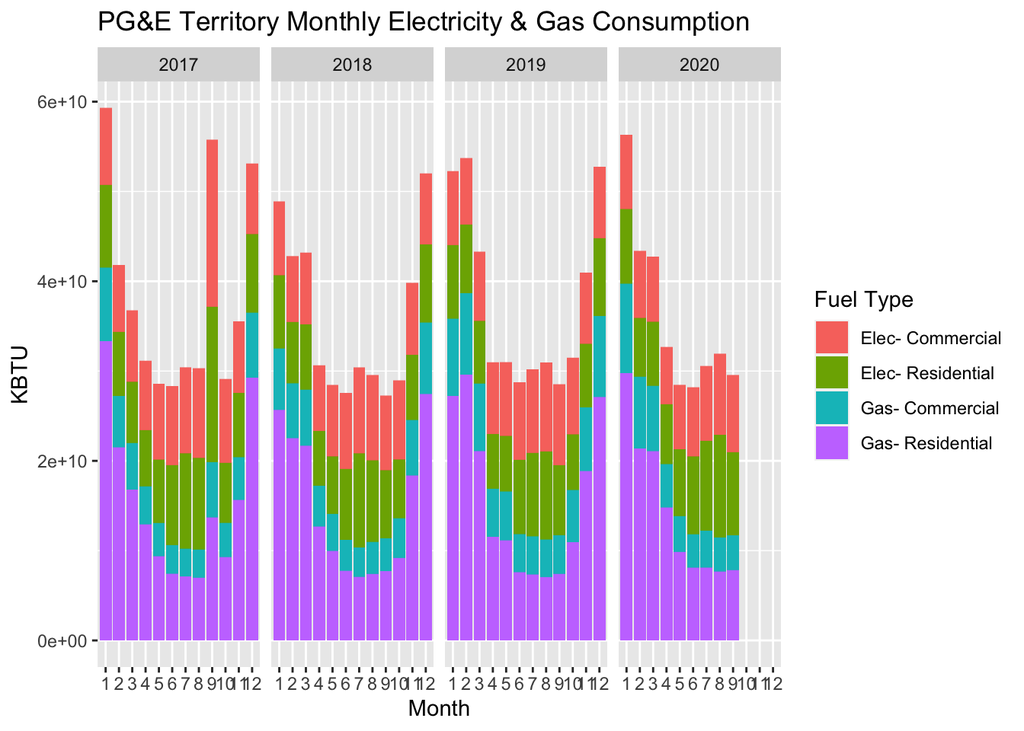

```r
pge_chart <-
  pge_all %>%
  ggplot() +
  geom_bar(
    aes(
      x = MONTH %>% factor(),
      y = TOTALKBTU,
      fill = CUSTOMERCLASS),
    stat = "identity",
    position = "stack") +
  facet_grid(~YEAR) +
  labs(
    x = "Month",
    y = "KBTU",
    title = "PG&E Territory Monthly Electricity & Gas Consumption",
    fill = "Fuel Type"
  )

pge_chart
```

*COMMENT:*

In all years we see predictable increases in both residential and commercial gas & electricity usage in the winter months (December - April), followed by significant decreases in the summer months. I would be curious to map this against the average temperature in these months, because I expect that for the winter months that were colder, average resource usage was higher.

The most significant outlier is September 2017, where it seems like there may be higher-than-average reported data.

In this view, is difficult to discern, comparing year to year, where the most significant changes occur on a monthly timeframe.

*Part 2:*

*Create at least one map that highlights which neighborhoods experienced the greatest change in electricity consumption before and after the pandemic began, and comment on your results. Explain any key assumptions you made in the analysis, or caveats about the data sources that you think the reader should be aware of. Publish all of this work in a web report.*

```r
projection <- "+proj=utm +zone=10 +ellps=GRS80 +datum=NAD83 +units=ft +no_defs"

bay_county_names <-
  c(
    "Alameda",
    "Contra Costa",
    "Marin",
    "Napa",
    "San Francisco",
    "San Mateo",
    "Santa Clara",
    "Solano",
    "Sonoma"
  )

bay_counties <-
  counties("CA", cb = T, progress_bar = F) %>%
  filter(NAME %in% bay_county_names)

usa_zips <-
  zctas(cb = T, progress_bar = F)
```

```
## ZCTAs can take several minutes to download.  To cache the data and avoid re-downloading in future R sessions, set `options(tigris_use_cache = TRUE)`
```

```r
bay_zips <-
  usa_zips %>%
  st_centroid() %>%
  .[bay_counties, ] %>%
  st_set_geometry(NULL) %>%
  left_join(usa_zips %>% select(GEOID10)) %>%
  st_as_sf()
```

```
## although coordinates are longitude/latitude, st_intersects assumes that they are planar
```

```
## although coordinates are longitude/latitude, st_intersects assumes that they are planar
```

```r
### Combining RESIDENTIAL gas & electric - mapping by zip code for 2020

pge_20_residential <-
  pge_all %>%
  filter(YEAR == 2020, CUSTOMERCLASS == "Elec- Residential" | CUSTOMERCLASS == "Gas- Residential" ) %>%
  mutate(
    ZIPCODE = ZIPCODE %>% as.character()
  ) %>%
  group_by(ZIPCODE) %>%
  summarize(
    TOTALKBTU = sum(TOTALKBTU, na.rm = T)
  ) %>%
  right_join(
    bay_zips %>% select(GEOID10),
    by = c("ZIPCODE" = "GEOID10")
  ) %>%
  st_as_sf() %>%
  st_transform(4326)
res_pal <- colorNumeric(
  palette = "Blues",
  domain =
    pge_20_residential$TOTALKBTU
)

leaflet() %>%
  addTiles()%>%
  addPolygons(
    data = pge_20_residential,
    fillColor = ~res_pal(TOTALKBTU),
    color = "white",
    opacity = 0.5,
    fillOpacity = 0.5,
    weight = 1,
    label = ~paste0(
      round(TOTALKBTU),
      " kBTU total in ",
      ZIPCODE
    ),
    highlightOptions = highlightOptions(
      weight = 2,
      opacity = 1
    )
  ) %>%
  addLegend(
    data = pge_20_residential,
    pal = res_pal,
    values = ~TOTALKBTU,
    title = "Total Residential<br>Gas & Electric<br>kBTU, 2020"
  )
```

[interactive chart not shown]

```r
###Identify change pre and post pandemic (comparing Apr-June 2019 to Apr-June 2020)

bay_pge_change <-
  pge_all %>%
  filter(
    CUSTOMERCLASS %in% c(
      "Elec- Residential"
    ),
    YEAR %in% 2019:2020,
    MONTH %in% 4
  ) %>%
  group_by(ZIPCODE,CUSTOMERCLASS,YEAR) %>%
  summarize(
    SPRINGKBTU = mean(TOTALKBTU, na.rm = T)
  ) %>%
  unite(
    key,
    c(CUSTOMERCLASS,YEAR),
    sep = "- "
  ) %>%
  pivot_wider(
    names_from = key,
    values_from = SPRINGKBTU
  ) %>%
  mutate(
    elec_res_change =
      (`Elec- Residential- 2020`/
         `Elec- Residential- 2019` - 1) * 100
  ) %>%
  left_join(
    bay_zips %>%
      transmute(ZIPCODE = ZCTA5CE10 %>% as.numeric())
  ) %>%
  st_as_sf()
elec_res_change <-
  bay_pge_change %>%
  filter(
    is.finite(elec_res_change),
    elec_res_change > -100
  )

elec_res_change_pal<- colorNumeric(
  palette = "PRGn",
  domain =
    elec_res_change$elec_res_change
)

leaflet() %>%
  addProviderTiles(providers$CartoDB.Positron) %>%
  addPolygons(
    data = elec_res_change,
    fillColor = ~elec_res_change_pal(elec_res_change),
    color = "white",
    fillOpacity = 0.75,
    weight = 1,
    label = ~paste0(
      round(elec_res_change),
      " % change in kBTU total in ",
      ZIPCODE
    ),
    highlightOptions = highlightOptions(
      weight = 2
    )
  ) %>%
  addLegend(
    data = elec_res_change,
    pal = elec_res_change_pal,
    values = ~elec_res_change,
    title = "% Change kBTU<br>Residential Electricity pre-COVID and post-COVID"
  )
```

[interactive chart not shown]

We see that across the board, there were significant increases in residential electricity usage. The majority of zip codes saw 10-20% electricity increases, with particularly (20%+) increases in some zip codes of San Francisco, Marin County, Santa Rosa, San Jose, and some of the suburbs on the edges around the Bay Area counties. One zip code in Oakland (94612) reported a -84% change, which I assume is an outlier and might need to be removed in future analysis.

Assumptions or factors not considered include: - There is no normalizing here for population size - some zip codes may have higher usage this year because, say, they had more residents in their zip code now than last year. - Again, we assume that the temperature and other (non-COVID) factors influencing electricity usage are not significantly different between 2019 and 2020.